# Host Source Choice Analysis

Load the Sun Shade header file:

```r
source("_sun_shade_header.R")
```

Load choice data:

```r
chP <- read.table("./data/sun_shade_choice/wholeplant.txt",T,"\t")
chL <- read.table("./data/sun_shade_choice/leafassay.txt",T,"\t")
chL$cage <- factor(chL$cage)
```

### Plots

Plot the data for Fig. 1b (whole-plant choice assay):

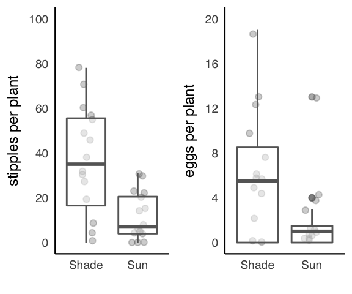

```r
# generate plots:
# summed counts across plants:
chP2 <- dplyr::group_by(chP, env, plant) %>% summarise(n_eggs = sum(eggs), n_stips = sum(stipples))
wp.stip <- ggplot(chP2, aes(x = env, y = n_stips)) +
  geom_jitter(width = 0.15, alpha = 0.3, col = "gray40") +
  geom_boxplot(alpha = 0.5, col = "gray40") + theme_pth1() +
  scale_y_continuous(limits = c(0,100), breaks = seq(0,100,20)) + xlab("") + ylab("stipples per plant")

wp.eggs <- ggplot(chP2, aes(x = env, y = n_eggs)) +
  geom_jitter(width = 0.15, alpha = 0.3, col = "gray40") +
  geom_boxplot(alpha = 0.5, col = "gray40") + theme_pth1() +
  scale_y_continuous(limits = c(0,20), breaks = seq(0,20,4)) + xlab("") + ylab("eggs per plant")

ggarrange(plotlist = list(wp.stip,wp.eggs))
```

Plot the data for Fig. 1c (detached leaf assay)

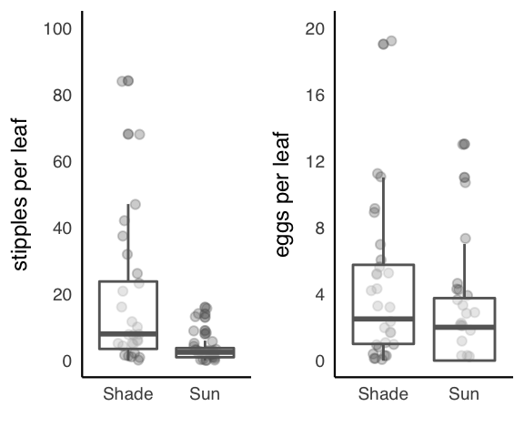

```r
dl.stip <- ggplot(chL, aes(x = env, y = stipples)) +
  geom_jitter(width = 0.15, alpha = 0.3, col = "gray40") +
  geom_boxplot(alpha = 0.5, col = "gray40") + theme_pth1() +
  scale_y_continuous(limits = c(0,100), breaks = seq(0,100,20)) + xlab("") + ylab("stipples per leaf")


dl.eggs <- ggplot(chL, aes(x = env, y = eggs)) +
  geom_jitter(width = 0.15, alpha = 0.3, col = "gray40") +
  geom_boxplot(alpha = 0.5, col = "gray40") + theme_pth1() +
  scale_y_continuous(limits = c(0,20), breaks = seq(0,20,4)) + xlab("") + ylab("eggs per leaf")

ggarrange(plotlist = list(dl.stip,dl.eggs))
```

### Whole-plant assay

#### Stipples

Run models:

```r
chp.lm0 <- glmmTMB(stipples ~ 1 + (1|cage) + (1|plant), data = chP, family = nbinom2)
chp.lm1 <- glmmTMB(stipples ~ leafnum + (1|cage) + (1|plant), data = chP, family = nbinom2)
chp.lm2 <- glmmTMB(stipples ~ leafnum + env + (1|cage) + (1|plant), data = chP, family = nbinom2)
chp.lm3 <- glmmTMB(stipples ~ leafnum + env + (1|cage) + (1|plant), data = chP,
                   zi = ~1, family = nbinom2)
chp.lm4 <- glmmTMB(stipples ~ leafnum + env + (1|cage) + (1|plant), data = chP,
                   zi = ~ env, family = nbinom2)
chp.lm5 <- glmmTMB(stipples ~ leafnum + env + (1|cage) + (1|plant), data = chP,
                   dispformula = ~ 0 + env, family = nbinom2)
chp.lm6 <- glmmTMB(stipples ~ leafnum + env + (1|cage) + (1|plant), data = chP,
                   dispformula = ~ 0 + env, zi = ~1, family = nbinom2)
chp.lm7 <- glmmTMB(stipples ~ leafnum + env + (1|cage) + (1|plant), data = chP,
                   dispformula = ~ 0 + env, zi = ~env, family = nbinom2)
```

Output model comparisons via $\Delta \text{AIC}_c$:

```r
ICtab(chp.lm0,chp.lm1,chp.lm2,chp.lm3,chp.lm4,chp.lm5,chp.lm6,type = 'AICc')
```

```
##         dAICc df
## chp.lm6  0.0  8
## chp.lm5  0.4  7
## chp.lm4  2.7  8
## chp.lm2  3.8  6
## chp.lm3  5.1  7
## chp.lm1  8.5  5
## chp.lm0 33.1  4
```

Output coefficient estimates for best model:

```r
# best model, based on parsimony and very little marginal improvement with one extra df for chp.lm6:
chp.s.bm <- chp.lm5
chp.stips <- confint(chp.s.bm)
chp.stips.coef <- do.call(rbind,summary(chp.s.bm)$coef)
round(chp.stips,2)
```

```
##                                2.5 % 97.5 % Estimate
## cond.(Intercept)                1.06   2.58     1.82
## cond.leafnum                   -0.26  -0.12    -0.19
## cond.envSun                    -1.89  -0.29    -1.09
## cond.Std.Dev.plant.(Intercept)  0.57   1.56     0.94
## cond.Std.Dev.cage.(Intercept)   0.21   1.59     0.57
## sigma                           0.42   0.84     0.59
## sigma                           0.19   0.47     0.30
```

Simulate best stipple model:

```r
set.seed(12345)
chp.s.sim  <- simulate(chp.s.bm,  nsim = 1000)
```

Predictive model check for $p(0)_i$ and $\mu_i$:

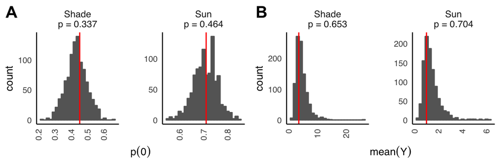

```r
chp.s.pp <- pp.plots(thesim = chp.s.sim, thedat = chP, thefact = 'env', theresponse = 'stipples')
print(chp.s.pp$plots)
```

Print summary of test statistics:

```r
print(chp.s.pp$means)
```

```
## # A tibble: 2 x 4
##     fact      mu2     lower    upper
##   <fctr>    <dbl>     <dbl>    <dbl>
## 1  Shade 4.498024 1.8789157 9.898042
## 2    Sun 1.392626 0.5577632 3.079342
```

```r
print(chp.s.pp$p0)
```

```
## # A tibble: 2 x 4
##                fact1        p0     lower     upper
##               <fctr>     <dbl>     <dbl>     <dbl>
## 1 "Shade\np = 0.337" 0.4318976 0.3072289 0.5542169
## 2   "Sun\np = 0.464" 0.7070421 0.6052632 0.8000000
```

```r
print(chp.s.pp$intensity)
```

```
## # A tibble: 2 x 4
##     fact      mu2    lower     upper
##   <fctr>    <dbl>    <dbl>     <dbl>
## 1  Shade 7.789236 3.898101 15.762011
## 2    Sun 4.652486 2.431578  9.727708
```

#### Eggs (whole-plant assay)

Run models:

```r
chp.e.lm0 <- glmmTMB(eggs ~ 1 + (1|cage) + (1|plant), data = chP, family = nbinom2)
chp.e.lm1 <- glmmTMB(eggs ~ leafnum + (1|cage) + (1|plant), data = chP, family = nbinom2)
chp.e.lm2 <- glmmTMB(eggs ~ leafnum + env + (1|cage) + (1|plant), data = chP, family = nbinom2)
chp.e.lm3 <- glmmTMB(eggs ~ leafnum + env + (1|cage) + (1|plant), data = chP,
                     zi = ~1, family = nbinom2)
chp.e.lm4 <- glmmTMB(eggs ~ leafnum + env + (1|cage) + (1|plant), data = chP,
                     zi = ~ env, family = nbinom2)
chp.e.lm5 <- glmmTMB(eggs ~ leafnum + env + (1|cage) + (1|plant), data = chP,
                     dispformula = ~ 0 + env, family = nbinom2)
chp.e.lm6 <- glmmTMB(eggs ~ leafnum + env + (1|cage) + (1|plant), data = chP,
                     dispformula = ~ 0 + env, zi = ~1, family = nbinom2)
chp.e.lm7 <- glmmTMB(eggs ~ leafnum + env + (1|cage) + (1|plant), data = chP,
                     dispformula = ~ 0 + env, zi = ~env, family = nbinom2)
```

Compare models via $\Delta AICc$:

```r
ICtab(chp.e.lm0,chp.e.lm1,chp.e.lm2,chp.e.lm3,chp.e.lm4,
      chp.e.lm5,chp.e.lm6,chp.e.lm7,type = 'AICc')
```

```
##           dAICc df
## chp.e.lm2  0.0  6
## chp.e.lm5  1.9  7
## chp.e.lm3  2.0  7
## chp.e.lm4  3.7  8
## chp.e.lm6  3.9  8
## chp.e.lm1  6.4  5
## chp.e.lm0 44.2  4
## chp.e.lm7   NA  9
```

Output coefficient estimates of best model:

```r
# best model:
chp.e.bm <- chp.e.lm2
chp.e <- confint(chp.e.bm)
chp.e.coef <- do.call(rbind,summary(chp.e.bm)$coef)
round(chp.e,2)
```

```
##                                2.5 % 97.5 % Estimate
## cond.(Intercept)                0.15   2.01     1.08
## cond.leafnum                   -0.58  -0.29    -0.43
## cond.envSun                    -2.40  -0.56    -1.48
## cond.Std.Dev.plant.(Intercept)  0.21   2.28     0.69
## cond.Std.Dev.cage.(Intercept)   0.00    Inf     0.00
## sigma                           0.14   0.54     0.27
```

Simulate best egg:

```r
set.seed(12345)
chp.e.sim  <- simulate(chp.e.bm,  nsim = 1000)
```

Predictive model check for $p(0)_i$ and $\mu_i$:

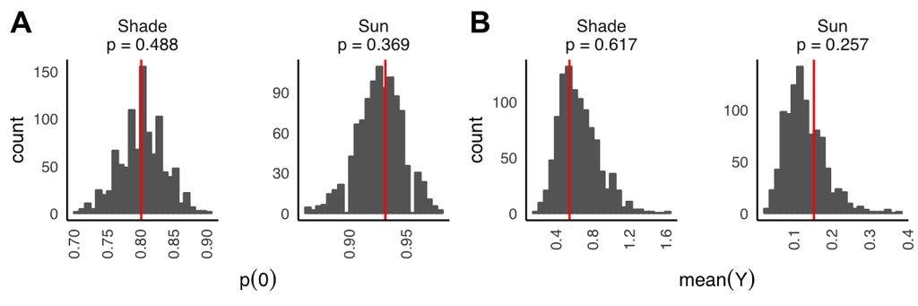

```r
chp.e.pp <- pp.plots(thesim = chp.e.sim, thedat = chP, thefact = 'env', theresponse = 'eggs')
print(chp.e.pp$plots)
```

Print summary of test statistics:

```r
print(chp.e.pp$means)
```

```
## # A tibble: 2 x 4
##     fact       mu2      lower     upper
##   <fctr>     <dbl>      <dbl>     <dbl>
## 1  Shade 0.6452530 0.31897590 1.1025602
## 2    Sun 0.1282895 0.04736842 0.2473684
```

```r
print(chp.e.pp$p0)
```

```
## # A tibble: 2 x 4
##                fact1        p0     lower     upper
##               <fctr>     <dbl>     <dbl>     <dbl>
## 1 "Shade\np = 0.488" 0.8025602 0.7408133 0.8674699
## 2   "Sun\np = 0.369" 0.9265316 0.8842105 0.9631579
```

```r
print(chp.e.pp$intensity)
```

```
## # A tibble: 2 x 4
##     fact      mu2    lower    upper
##   <fctr>    <dbl>    <dbl>    <dbl>
## 1  Shade 3.261327 1.938909 5.428887
## 2    Sun 1.734807 1.083333 2.909280
```

### Detached leaf assay

#### Stipples (detached leaf assay)

Run models:

```r
chl.lm0 <- glmmTMB(stipples ~ 1 + (1|cage), data = chL, family = nbinom2)
chl.lm1 <- glmmTMB(stipples ~ area + (1|cage), data = chL, family = nbinom2)
chl.lm2 <- glmmTMB(stipples ~ area + env + (1|cage), data = chL, family = nbinom2)
chl.lm3 <- glmmTMB(stipples ~ area + env + (1|cage), data = chL,
                   zi = ~1, family = nbinom2)
chl.lm4 <- glmmTMB(stipples ~ area + env + (1|cage), data = chL,
                   zi = ~env, family = nbinom2)
chl.lm5 <- glmmTMB(stipples ~ area + env + (1|cage), data = chL,
                   dispformula = ~ env, family = nbinom2)
chl.lm6 <- glmmTMB(stipples ~ area + env + (1|cage), data = chL,
                   dispformula = ~ env, zi = ~1, family = nbinom2)
chl.lm7 <- glmmTMB(stipples ~ area + env + (1|cage), data = chL,
                   dispformula = ~ env, zi = ~env, family = nbinom2)
```

Compare models via $\Delta AICc$:

```r
ICtab(chl.lm0,chl.lm1,chl.lm2,chl.lm3,chl.lm4,chl.lm5,chl.lm6,chl.lm7,type = 'AICc')
```

```
##         dAICc df
## chl.lm2  0.0  5
## chl.lm5  1.1  6
## chl.lm3  2.5  6
## chl.lm6  3.7  7
## chl.lm4  5.0  7
## chl.lm7  6.3  8
## chl.lm0 23.1  3
## chl.lm1 25.3  4
```

Output coefficient estimates of best model:

```r
# best model
chl.bm <- chl.lm2
chl.stips <- confint(chl.bm)
chl.stips.coef <- do.call(rbind,summary(chl.bm)$coef)
round(chl.stips,2)
```

```
##                               2.5 % 97.5 % Estimate
## cond.(Intercept)               0.76   3.78     2.27
## cond.area                     -0.06   0.13     0.03
## cond.envSun                   -2.34  -1.20    -1.77
## cond.Std.Dev.cage.(Intercept)  0.60   1.89     1.07
## sigma                          0.71   1.86     1.15
```

Simulate best stipple model:

```r
set.seed(12345)
chl.sim  <- simulate(chl.bm,  nsim = 1000)
```

Predictive model check for $p(0)_i$ and $\mu_i$:

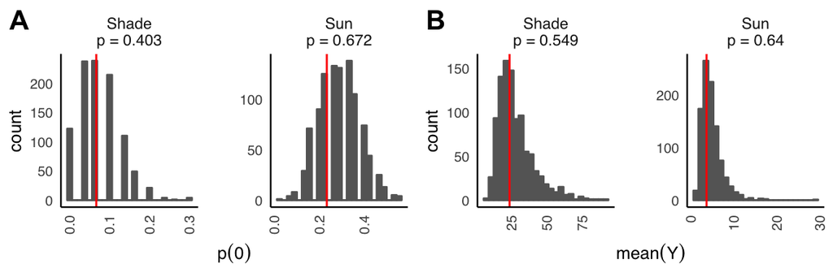

```r
chl.pp <- pp.plots(thesim = chl.sim, thedat = chL, thefact = 'env', theresponse = 'stipples')
print(chl.pp$plots)
```

Print summary of test statistics:

```r
print(chl.pp$means)
```

```
## # A tibble: 2 x 4
##     fact       mu2     lower   upper
##   <fctr>     <dbl>     <dbl>   <dbl>
## 1  Shade 27.906500 12.098333 60.7825
## 2    Sun  4.767567  1.833333 10.9000
```

```r
print(chl.pp$p0)
```

```
## # A tibble: 2 x 4
##                fact1     p0     lower     upper
##               <fctr>  <dbl>     <dbl>     <dbl>
## 1 "Shade\np = 0.403" 0.0746 0.0000000 0.2000000
## 2   "Sun\np = 0.672" 0.2950 0.1333333 0.4666667
```

```r
print(chl.pp$intensity)
```

```
## # A tibble: 2 x 4
##     fact       mu2    lower    upper
##   <fctr>     <dbl>    <dbl>    <dbl>
## 1  Shade 30.112176 13.34454 66.35738
## 2    Sun  6.725147  2.87500 14.44347
```

#### Eggs (detached leaf assay)

Run models:

```r
chl.e.lm0 <- glmmTMB(eggs ~ 1 + (1|cage), data = chL, family = nbinom2)
chl.e.lm1 <- glmmTMB(eggs ~ area + (1|cage), data = chL, family = nbinom2)
chl.e.lm2 <- glmmTMB(eggs ~ area + env + (1|cage), data = chL, family = nbinom2)
chl.e.lm3 <- glmmTMB(eggs ~ area + env + (1|cage), data = chL,
                     zi = ~1, family = nbinom2)
chl.e.lm4 <- glmmTMB(eggs ~ area + env + (1|cage), data = chL,
                     zi = ~env, family = nbinom2)
chl.e.lm5 <- glmmTMB(eggs ~ area + env + (1|cage), data = chL,
                     dispformula = ~ env, family = nbinom2)
chl.e.lm6 <- glmmTMB(eggs ~ area + env + (1|cage), data = chL,
                     dispformula = ~ env, zi = ~1, family = nbinom2)
chl.e.lm7 <- glmmTMB(eggs ~ area + env + (1|cage), data = chL,
                     dispformula = ~ env, zi = ~env, family = nbinom2)
```

Compare models via $\Delta \text{AIC}_c$:

```r
ICtab(chl.e.lm0,chl.e.lm1,chl.e.lm2,chl.e.lm3,chl.e.lm4,
      chl.e.lm5,chl.e.lm6,chl.e.lm7,type = 'AICc')
```

```
##           dAICc df
## chl.e.lm0 0.0   3
## chl.e.lm2 1.2   5
## chl.e.lm1 2.0   4
## chl.e.lm5 3.3   6
## chl.e.lm3 3.4   6
## chl.e.lm4 4.2   7
## chl.e.lm6 5.7   7
## chl.e.lm7 6.4   8
```

Best model is in fact intercept-only model.. elaborate with dispersion and ZI terms and re-compare:

```r
chl.e.lm0.d1 <- glmmTMB(eggs ~ 1 + (1|cage), zi = ~1, data = chL, family = nbinom2)
chl.e.lm0.d2 <- glmmTMB(eggs ~ 1 + (1|cage), zi = ~env, data = chL, family = nbinom2)
chl.e.lm0.d3 <- glmmTMB(eggs ~ 1 + (1|cage), dispformula = ~ env, data = chL, family = nbinom2)
chl.e.lm0.d4 <- glmmTMB(eggs ~ 1 + (1|cage), dispformula = ~ env,
                        zi = ~1, data = chL, family = nbinom2)
chl.e.lm0.d5 <- glmmTMB(eggs ~ 1 + (1|cage), dispformula = ~ env,
                        zi = ~env, data = chL, family = nbinom2)

ICtab(chl.e.lm0,chl.e.lm1,chl.e.lm2,chl.e.lm3,chl.e.lm4,chl.e.lm5,chl.e.lm6,
      chl.e.lm7,chl.e.lm0.d1,chl.e.lm0.d2,chl.e.lm0.d3,chl.e.lm0.d4,chl.e.lm0.d5,
      type = 'AICc')
```

```
##              dAICc df
## chl.e.lm0.d2 0.0   5
## chl.e.lm0    0.2   3
## chl.e.lm0.d1 0.3   4
## chl.e.lm2    1.4   5
## chl.e.lm0.d3 1.5   4
## chl.e.lm0.d5 1.5   6
## chl.e.lm1    2.3   4
## chl.e.lm0.d4 2.7   5
## chl.e.lm5    3.6   6
## chl.e.lm3    3.7   6
## chl.e.lm4    4.4   7
## chl.e.lm6    5.9   7
## chl.e.lm7    6.6   8
```

In main text, we will report coefficients and predictions from non-optimal model, but report that best model was intercept-only with ZI term.

Output coefficient estimates of model to report:

```r
# model to report
chl.e.bm <- chl.e.lm2
chl.eggs <- confint(chl.e.bm)
chl.eggs.coef <- do.call(rbind,summary(chl.e.bm)$coef)
round(chl.eggs,2)
```

```
##                               2.5 % 97.5 % Estimate
## cond.(Intercept)              -0.69   2.54     0.93
## cond.area                     -0.09   0.13     0.02
## cond.envSun                   -1.18   0.04    -0.57
## cond.Std.Dev.cage.(Intercept)  0.31   1.79     0.75
## sigma                          0.56   2.40     1.15
```

Simulate chosen egg model:

```r
set.seed(12345)
chl.e.sim  <- simulate(chl.e.bm,  nsim = 1000)
```

Predictive model check for $p(0)_i$ and $\mu_i$:

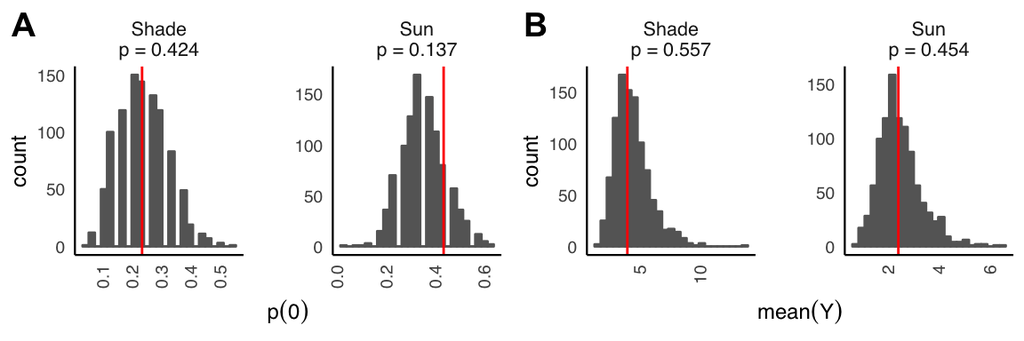

```r
chl.e.pp <- pp.plots(thesim = chl.e.sim, thedat = chL, thefact = 'env', theresponse = 'eggs')
print(chl.e.pp$plots)
```

Output summary of test statistics:

```r
print(chl.e.pp$means)
```

```
## # A tibble: 2 x 4
##     fact      mu2    lower    upper
##   <fctr>    <dbl>    <dbl>    <dbl>
## 1  Shade 4.394133 2.265833 8.000833
## 2    Sun 2.463567 1.166667 4.269167
```

```r
print(chl.e.pp$p0)
```

```
## # A tibble: 2 x 4
##                fact1        p0 lower     upper
##               <fctr>     <dbl> <dbl>     <dbl>
## 1 "Shade\np = 0.424" 0.2368000   0.1 0.4000000
## 2   "Sun\np = 0.137" 0.3505333   0.2 0.5333333
```

```r
print(chl.e.pp$intensity)
```

```
## # A tibble: 2 x 4
##     fact      mu2    lower   upper
##   <fctr>    <dbl>    <dbl>   <dbl>
## 1  Shade 5.739588 3.285238 9.84200
## 2    Sun 3.786995 2.166667 6.50125
```

Note that the predictive response distributions all overlap for the two habitat source types.

### Output model coefficients:

```r
OUTDIR <- "./model_output/"

# # chP stipples
# write.table(chp.stips, file = paste0(OUTDIR,"chp.stips_ci.txt"), sep = '\t')
# write.table(chp.stips.coef, file = paste0(OUTDIR,"chp.stips_coef.txt"), sep = '\t')
#
# # chP eggs
# write.table(chp.e, file = paste0(OUTDIR,"chp.eggs_ci.txt"), sep = '\t')
# write.table(chp.e.coef, file = paste0(OUTDIR,"chp.eggs_coef.txt"), sep = '\t')
#
# # chL stipples
# write.table(chl.stips, file = paste0(OUTDIR,"chl.stips_ci.txt"), sep = '\t')
# write.table(chl.stips.coef, file = paste0(OUTDIR,"chl.stips_coef.txt"), sep = '\t')
#
# # chL eggs
# write.table(chl.eggs, file = paste0(OUTDIR,"chl.eggs_ci.txt"), sep = '\t')
# write.table(chl.eggs.coef, file = paste0(OUTDIR,"chl.eggs_coef.txt"), sep = '\t')
```